# Reproducible Research: Peer Assessment 1

#Reproducible Research: Peer Assessment 1

## Loading and preprocessing the data

### 1. Load the data (e.g. read.csv())

```r
# First, use setwd() to the right folder. I skipped this step here since different people store the file at different places.

# Second, unzip the file to obtain the csv file. Although Mac will automatically unzip the file upon downloading finish. I'll still do this step in case other plateforms do not have this.

if (!file.exists("activity.csv")){
    unzip ("activity.zip")
}
AllData <- read.csv("activity.csv")
```

### 2. Process/transform the data (if necessary) into a format suitable for your analysis

```r
# Third, remove all incomplet cases to tidy the data
CompleteData <- AllData[complete.cases(AllData),]
```

## What is mean total number of steps taken per day?

### 1. Calculate the total number of steps taken per day

```r
# We will use the aggregate function to calculate all steps listed.
Total_Steps_Per_Day <- aggregate(steps ~ date, CompleteData, sum)
```

### 2. If you do not understand the difference between a histogram and a barplot, research the difference between them. Make a histogram of the total number of steps taken each day

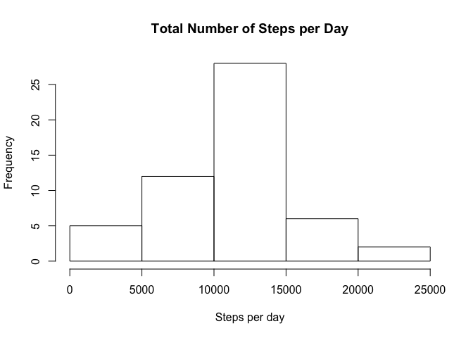

```r
# We will create a histal gram showing the steps per day. Here, we will use standard breaks since it is not required.
hist(Total_Steps_Per_Day$steps, main = "Total Number of Steps per Day", xlab = "Steps per day")
```

### 3. Calculate and report the mean and median of the total number of steps taken per day

```r
# We will calculate the mean and the media seperately.
# First, the mean. Note that we will round it to the nearest integer
Mean_Steps_Per_Day <- round(mean(Total_Steps_Per_Day$steps))

# Second, the median
Median_Steps_Per_Day <- median(Total_Steps_Per_Day$steps)

# Lastly, print out the data
print(paste("The mean steps per day is", Mean_Steps_Per_Day,
            "and the median steps per day is", Median_Steps_Per_Day,
            "(rounded to the nearest integer)"))
```

```
## [1] "The mean steps per day is 10766 and the median steps per day is 10765 (rounded to the nearest integer)"
```

## What is the average daily activity pattern?

### 1. Make a time series plot (i.e. type = “l”) of the 5-minute interval (x-axis) and the average number of steps taken, averaged across all days (y-axis)

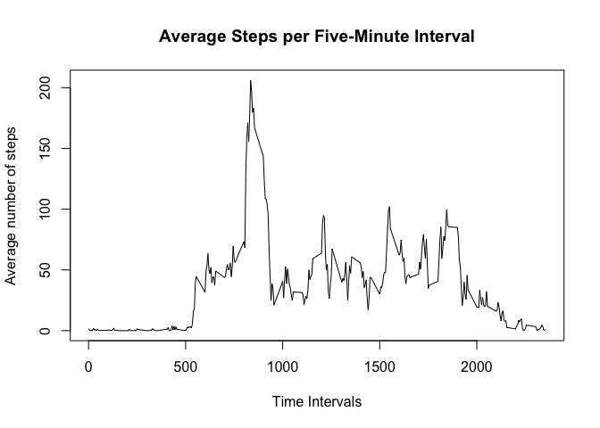

```r
# First, we need to calulate the average steps per 5-min interval:
Avg_Steps_per_Interval <- aggregate(steps ~ interval,CompleteData, mean)

# Second, generate the time serises plot.
plot(Avg_Steps_per_Interval$interval, Avg_Steps_per_Interval$steps, type = "l",
     main = "Average Steps per Five-Minute Interval",
     xlab = "Time Intervals", ylab = "Average number of steps")
```

### 2. Which 5-minute interval, on average across all the days in the dataset, contains the maximum number of steps?

```r
# To do this, we need to find out the intervel index at which the highest steps appears and print it out.
# Note that the steps are ronded to the nearest integer.
StepMax <- which.max(Avg_Steps_per_Interval$steps)

print(paste("At interval", Avg_Steps_per_Interval[StepMax,]$interval,
            "the highest steps appear, which is",
            round(Avg_Steps_per_Interval[StepMax,]$steps, digits = 0),
            "steps (rounded to the nearest integer)"))
```

```
## [1] "At interval 835 the highest steps appear, which is 206 steps (rounded to the nearest integer)"
```